# Project 2

### Created by Asif Chowdhury, Justin Owens, Jash Choraria

This is the second project for CS 329E Data Visualization. The data we will analyze comes from the World Health Organization. The topic is cause of child deaths for different age groups in the United States, China, Germany and Japan. In order to reproduce this project, please follow the following instructions.

## Step 1

#### Load the correct packages

Use the following code to load the correct packages into RStudio.

```r
source("../01 Data/Packages.R", echo = TRUE)
```

```
##
## > require(plyr)
##
## > require(dplyr)
##
## > require(ggplot2)
##
## > require(knitr)
##
## > require(reshape2)
##
## > require(RCurl)
##
## > require(grid)
##
## > require(plyr)
##
## > require(gplots)
##
## > require(tidyr)
```

## Step 2

#### Import the data from the Oracle cloud server.

The data table has 10 columns of information, but the columns we will be focusing on are as follows: CAUSESOFDEATH, YEAR, WHOREGION, COUNTRY, AGEGROUP, and NUMERIC.

```r
source("../01 Data/GetDB.R", echo = TRUE)
```

```
##
## > df <- data.frame(eval(parse(text = substring(getURL(URLencode("http://129.152.144.84:5001/rest/native/?query=\"select * from childdeaths\""),
## +     .... [TRUNCATED]
```

## Step 3

#### Create a new dataframe.

After getting the data table from the server, we can extract only the columns we want, those discussed above.

```r
source("../01 Data/Actual_data.R", echo = TRUE)
```

```
##
## > actual_data <- df %>% select(CAUSESOFDEATH, YEAR,
## +     WHOREGION, COUNTRY, AGEGROUP, NUMERIC)
##
## > head(actual_data)
##                                           CAUSESOFDEATH YEAR WHOREGION
## 1 Sepsis and other infectious conditions of the newborn 2002  Americas
## 2                                              Injuries 2010  Americas
## 3                    Acute lower respiratory infections 2005  Americas
## 4                                  Congenital anomalies 2013  Americas
## 5                                              Injuries 2000  Americas
## 6                                               Measles 2005  Americas
##                    COUNTRY    AGEGROUP    NUMERIC
## 1 United States of America   0-4 years  861.52911
## 2 United States of America    0-27 day  200.86620
## 3 United States of America 1-59 months  913.43988
## 4 United States of America    0-27 day 4296.86621
## 5 United States of America 1-59 months 3489.17407
## 6 United States of America   0-4 years    1.77335
```

## Step 4

#### Use data wrangling to create smaller dataframes for visualizations.

The first visualization we will create will look at the average number of children deaths between the ages of 0 days to 59 months for each country. We will need to “wrangle” the data from our orignal table using this code:

```r
source("../02 Data Wrangling/Country_Death.R", echo = TRUE)
```

```
##
## > Country_Death <- actual_data %>% group_by(COUNTRY) %>%
## +     summarise(MEAN_DEATH = round(mean(NUMERIC)))
##
## > tbl_df(Country_Death)
## Source: local data frame [4 x 2]
##
##                    COUNTRY MEAN_DEATH
## 1                    China      17516
## 2                  Germany        149
## 3                    Japan        180
## 4 United States of America       1416
```

The second visualization will look at the median number of child deaths for each of the countries and each of the age groups. We will need to “wrangle” the data from our orignal table using this code:

```r
source("../02 Data Wrangling/Country_AgeGroup.R", echo = TRUE)
```

```
##
## > Country_AgeGroup <- actual_data %>% group_by(COUNTRY,
## +     AGEGROUP) %>% summarise(MEDIAN_DEATH = round(median(NUMERIC))) %>%
## +     filter(COUNTR .... [TRUNCATED]
##
## > tbl_df(Country_AgeGroup)
## Source: local data frame [9 x 3]
##
##                    COUNTRY    AGEGROUP MEDIAN_DEATH
## 1                  Germany    0-27 day            7
## 2                  Germany   0-4 years           61
## 3                  Germany 1-59 months           25
## 4                    Japan    0-27 day           18
## 5                    Japan   0-4 years           90
## 6                    Japan 1-59 months           40
## 7 United States of America    0-27 day           89
## 8 United States of America   0-4 years          820
## 9 United States of America 1-59 months          210
```

The third visual will look at the total number of deaths over time separated by each cqause of death. We will need to “wrangle” the data from our original table using this code:

```r
source("../02 Data Wrangling/Year_Cause.R", echo = TRUE)
```

```
##
## > Year_Cause <- actual_data %>% group_by(YEAR, CAUSESOFDEATH) %>%
## +     filter(COUNTRY != "China") %>% summarise(sum = round(sum(NUMERIC)))
##
## > tbl_df(Year_Cause)
## Source: local data frame [210 x 3]
##
##    YEAR                                            CAUSESOFDEATH   sum
## 1  2000                       Acute lower respiratory infections  2882
## 2  2000                          Birth asphyxia and birth trauma  4023
## 3  2000                                     Congenital anomalies 23241
## 4  2000                                      Diarrhoeal diseases  1360
## 5  2000                                                 HIV/AIDS    92
## 6  2000                                                 Injuries  9224
## 7  2000                                                  Malaria     0
## 8  2000                                                  Measles    30
## 9  2000                                  Meningitis/encephalitis   911
## 10 2000 Other communicable, perinatal and nutritional conditions  6952
## ..  ...                                                      ...   ...
```

## Step 5

#### Use ggplot and the newly “wrangled” data frames to create interesting visuals.

We will now create the interesting visuals for all of the dataframes we have “wrangled” in step 4.

Visualization 1 - This visualization shows us the average death for each country for all causes for the entire time frame of the data. We can see that China’s average child death is significantly higher than that of Japan, the United States and Germany; therefore, we will ignore China in the next visuals and comparisons.

```r
source("../03 Visualizations/Country_Death.R", echo = TRUE)
```

```
##
## > ggplot(Country_Death, aes(x = COUNTRY, y = MEAN_DEATH,
## +     color = COUNTRY)) + geom_point(aes(size = 10000))
```

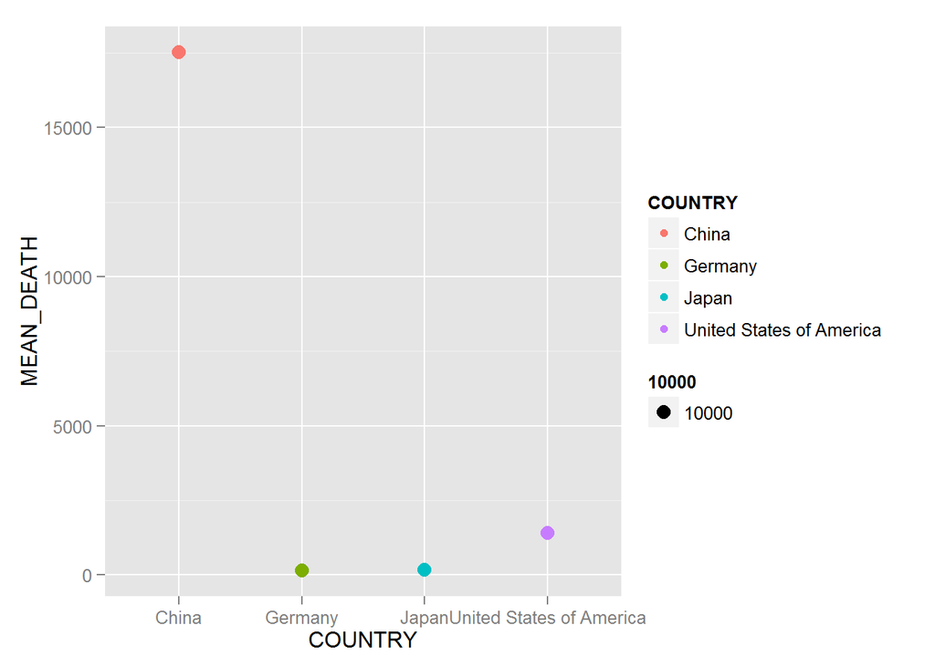

Visualization 2 - With China removed, we can now observe the median number of deaths in Germany, Japan and the United States individually by age group. We can tell that more children tend to die after 27 days and before 48months. The age groups do overlap, but seeing that the average amounts of deaths are higher in the 0-4 year range than the 0-27 day and 1-59 month ranges leads us to believe that more children die after 27 days and before 48 months. Overall, the United States had more childrens deaths.

```r
source("../03 Visualizations/Country_AgeGroup.R", echo = TRUE)
```

```
##
## > ggplot(Country_AgeGroup, aes(x = COUNTRY, y = MEDIAN_DEATH,
## +     color = COUNTRY)) + geom_point(aes(size = 10000)) + facet_wrap(~AGEGROUP)
```

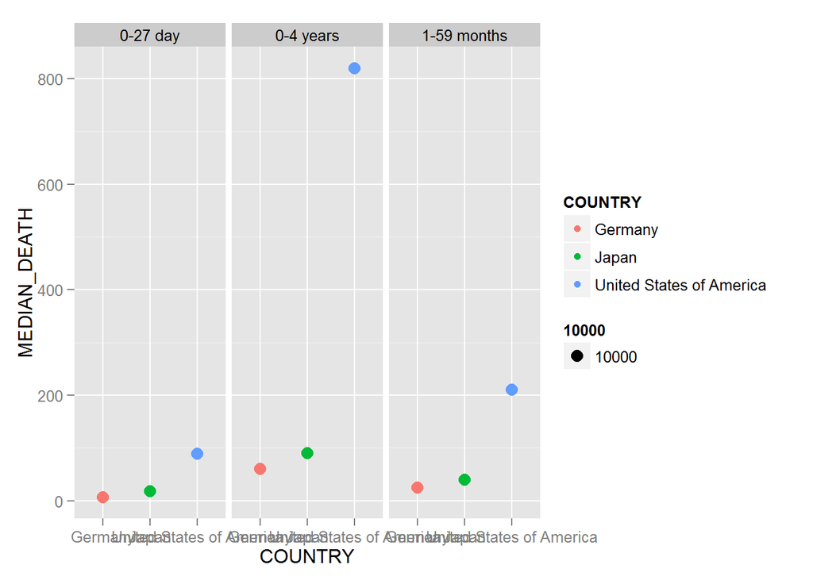

Visualization 3 - From this visual, we can see that the total number of childrens deaths due to all factors stayed relatively the same over time except with congenital anomalies and prematurity. There was an increase in the total childrens deaths caused by prematurity in 2005, and the deaths caused by congenital anomalies have decreased over time.

```r
source("../03 Visualizations/Year_Cause.R", echo = TRUE)
```

```
##
## > ggplot(Year_Cause, aes(x = YEAR, y = sum)) + geom_line() +
## +     facet_wrap(~CAUSESOFDEATH)
```

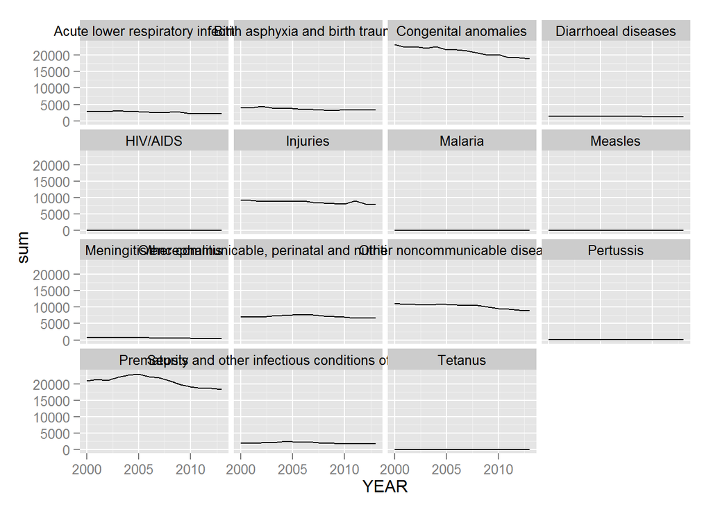